# Demand For Offense

Designated Hitters and MLB Attendance

Alexander Cardazzi

Old Dominion University

Zachary Rodriguez

Union College

## Literaure Review

Do sports teams maximize profits or wins?

- Profits: Ferguson et al. (1991); Hill and Jolly (2017)
- Wins: Garcia-del-Barrio and Szymanski (2009)

Fans have preferences for Superstars

- Humphreys and Johnson (2020)

Do fans have preferences for offense?

## NBA: Finals Viewership

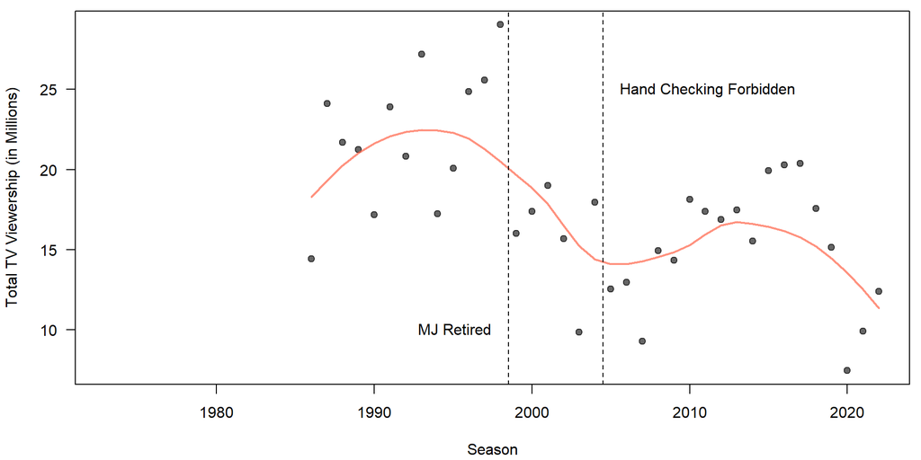

## MLB: World Series Viewership

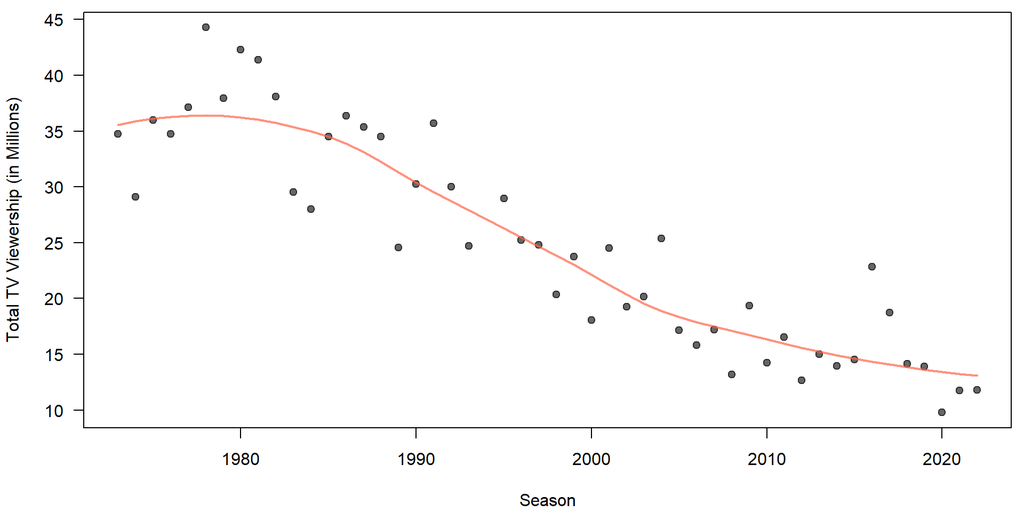

## Designated Hitters

1. DHs *must* take the place of pitchers in the batting order.
2. The DH position first appeared in the AL in 1973.
3. In 2022, the MLB made the DH position universal ([AL + NL](http://dhmontgomery.com/images/2011/11/MLBteamsmap1.jpg)).
   - The rule change occured following free agency.
4. National League teams struggled to adjust to the rule change last season.
   - NL DH output was substantially lower than that of their AL counterparts.
   - Even still, the DH position was substantially better than having pitchers bat.

[FanGraphs Chart](https://blogs.fangraphs.com/wp-content/uploads/2022/04/2022-Designated-Hitter-Positional-WAR-by-Team.png)

## Research Question & Findings

How did fans respond to this change in play?

## Data Sources

Regular season, game-level data (2013-2022)

- Attendance, Scores, Records, Location, etc.
- 20,458 MLB Games

## Data Sources

Regular season, game-level data (2013-2022)

- Attendance, Scores, Records, Location, etc.
- 20,458 MLB Games
  - Remove 2020 Season
  - Remove Blue Jays in 2021 (travel restrictions)
  - Remove all Houston Astros
  - Remove 28 games with missing beting information

Betting data

- Oddsshark.com for game-level odds
- Sportsoddshistory.com for pre- and within-season odds

## Summary Statistics

|  | Mean | St. Dev. | Min | Max |
| --- | --- | --- | --- | --- |
| Attendance (in 1,000s) | 28.407 | 10.961 | 1.832 | 59.659 |
| Capacity % | 0.650 | 0.240 | 0.044 | 1.580 |
| Home Win | 0.535 | 0.499 | 0 | 1 |
| Home Win Prob. | 54.053 | 10.302 | 20 | 83.333 |
| Home Score | 4.473 | 3.089 | 0 | 25 |
| Away Score | 4.357 | 3.156 | 0 | 28 |
| National League | 0.534 | 0.499 | 0 | 1 |
| Universal DH | 0.111 | 0.314 | 0 | 1 |

Note: Number of MLB Games = 20,458

## Home Team Attendance

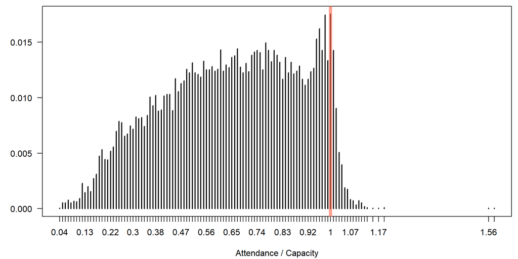

## Methodology

**Calculate differences in attendance between AL and NL stadiums before and after the DH rule.**

Control for game and team characteristics that might effect attendance. - Control for initial levels of attendance across leagues.

League wide trends will be captured via AL teams. - This is the “control” group in the experiment.

Any *additional* change in NL attendance is due to the DH rule.

## Methodology

Difference-in-differences:

$$\begin{align}
O_{itsomw} &= \delta (\text{NL}_t \times \text{DH}_s) + X_{itsom}\beta + \tau_s + \tau_{to} + \tau_{tm} + \tau_{tw} + \epsilon_{itsomw} \nonumber
\end{align}$$

**where:**

$O$ is outcome for game $i$ played by home team $t$ against opponent $o$ in season $s$ in month $m$ on weekend $w$.

$X_{itsom}$ is a vector of controls (wins, win percent, home team money line, pre-season O/U, and playoff odds)

Fixed Effects: Season, team-by-opponent, team-by-month, team-by-weekday, stadium

## Results – DH on Offense

Effect of DH on Offense

|  | O/U | Total Score | Home Score | Away Score |
| --- | --- | --- | --- | --- |
| NL x DH | 0.570 | 0.422 | 0.383 | 0.347 |
|  | (0.059)*** | (0.131)** | (0.091)*** | (0.391) |
|  | [0.034]*** | [0.214]** | [0.145]*** | [0.356] |
| Num.Obs. | 20458 | 20458 | 20458 | 9543 |
| R2 | 0.653 | 0.148 | 0.162 | 0.172 |

Note: This table presents how the universal DH rule affects offensive output. We identify statistically significant increases in offense using the over-under totals, total scores, and home scores. Adding further validity to our analysis, we find no effects for scores generated by NL teams playing in AL stadiums, where teams were using a DH the entire time. Standard errors in parentheses are clustered by team and season. Standard errors in brackets are heteroskedasticity robust.

## Runs in Home Games by League

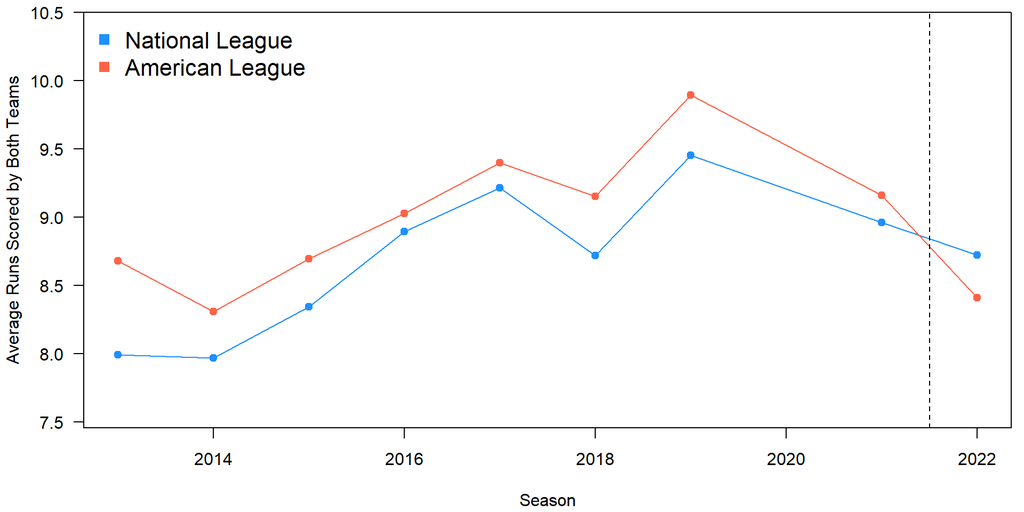

## Results – DH on Attendance

Effect of DH on Attendance

|  | Attendance | log(Attendance) | Att / Cap | Att / Cap (max) |
| --- | --- | --- | --- | --- |
| NL x DH | 1657.906 | 0.079 | 0.037 | 0.035 |
|  | (724.193)* | (0.035)* | (0.018)* | (0.017)* |
|  | [264.320]*** | [0.012]*** | [0.006]*** | [0.006]*** |
| Num.Obs. | 20458 | 20458 | 20458 | 20458 |
| R2 | 0.795 | 0.783 | 0.773 | 0.775 |

Note: This table displays the effects of the universal DH rule on attendance, defined in different ways. We find that attendance increases significantly regardless of how it is defined. Standard errors in parentheses are clustered by team and season. Standard errors in brackets are heteroskedasticity robust.

## Results – Event Studies

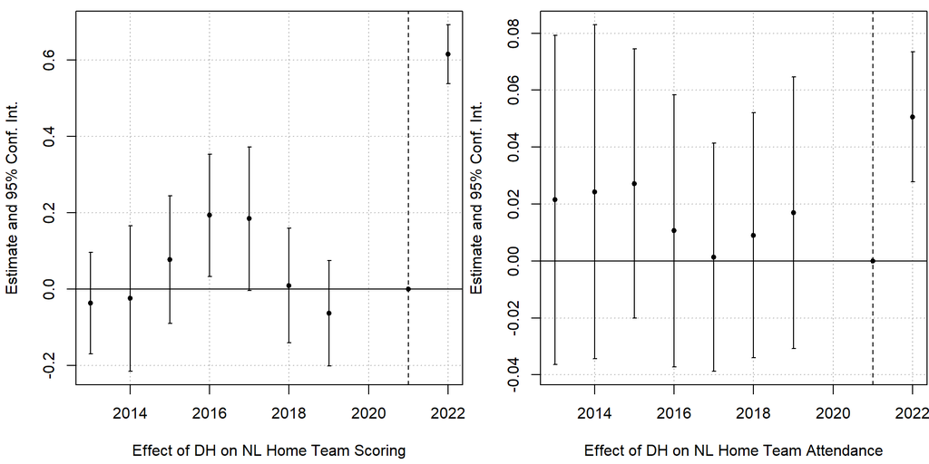

## Robustness – Ticket Prices

**We do not observe ticket prices!**

As demand increases (due to additional offense), prices should also increase.

- $\text{Offense} \uparrow \ \text{Price} \uparrow$

All else equal, increases in price will reduce attendance.

- $\text{Price} \uparrow \ \text{Attendance} \downarrow$

Since these correlations are **opposite** one another, our estimated (positive) coefficient is biased **downward**. In other words, our estimate is a *lower* bound.

## Robustness – Away Teams

What if NL teams are just better offensively?

- National League teams used DHs during interleague play prior to the rule change.
- Therefore, if NL teams are now better offensively, we should see an increase in offense when playing at AL stadiums after the DH rule.
- While our coefficient estimate is positive, we do not find statistical evidence (two-way or hetero) that there is a difference.

## Discussion

Current Draft

The MLB allowed NL teams to use DHs in the 2022 season.

Importantly, this is the first paper to *causally* quantify fan preferences for offense.

## 2023 MLB Rule Changes (via [MLB.com](https://www.mlb.com/news/mlb-new-rules-for-2023-faq))

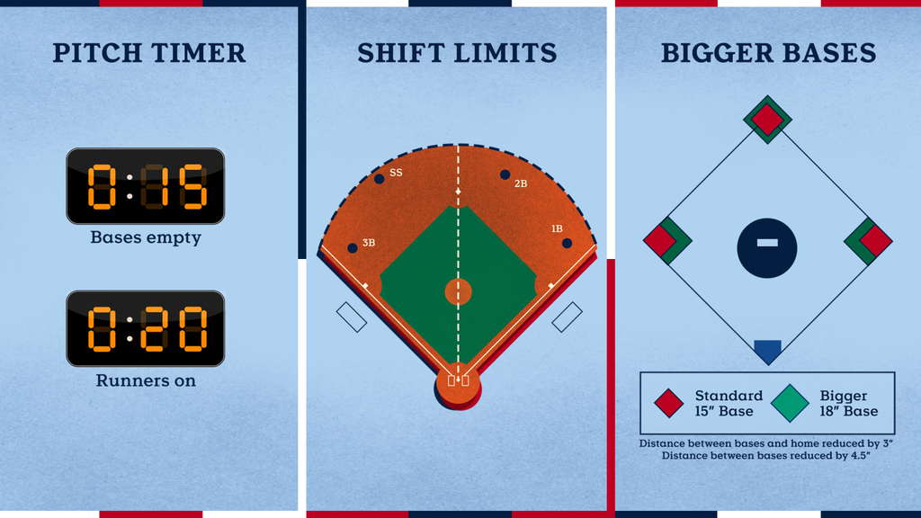

## Bibliography

Ferguson, Donald G, Kenneth G Stewart, JCH Jones, and Andre Le Dressay. 1991. “The Pricing of Sports Events: Do Teams Maximize Profit?” *The Journal of Industrial Economics*, 297–310.

Garcia-del-Barrio, Pedro, and Stefan Szymanski. 2009. “Goal! Profit Maximization Versus Win Maximization in Soccer.” *Review of Industrial Organization* 34: 45–68.

Hill, James Richard, and Nicholas A Jolly. 2017. “Revenue Sharing and Player Salaries in Major League Baseball.” *Journal of Sports Economics* 18 (8): 831–49.

Humphreys, Brad R, and Candon Johnson. 2020. “The Effect of Superstars on Game Attendance: Evidence from the NBA.” *Journal of Sports Economics* 21 (2): 152–75.

## Thanks!

[alexcardazzi.github.io](https://alexcardazzi.github.io/)

[zacharyrodriguez.net](https://www.zacharyrodriguez.net/)

## State Capacity of Secrets

- Surveillance should be balanced
  - Surveillance can both protect and hurt citizens
  - A (personally salient) parallel is speed limits
- Trust in government is important in determining civilian satisfaction
- Is there a way to identify a link using data? World Bank Surveys?
- Please send a draft, I will be happy to look it over!

Virginia Association of Economists